# Bellabeat Project

Benjamin B

2022-04-21

## Introduction - Welcome to BellaBeat Data Analysis Project

BellaBeat is a high-tech company that manufactures health-focused smart products. Collecting data on activity, sleep, stress, and reproductive health has allowed Bellabeat to empower women with knowledge about their own health and habits. Since it was founded in 2013, Bellabeat has grown rapidly and quickly positioned itself as a tech-driven wellness company for women.

## Business Task

Analyse Fitbit data to gain insight on possible growth opportunities for Bellabeat and improve it’s marketing strategy.

## Installing and Loading Key Packages

[output not shown]

[output not shown]

[output not shown]

[output not shown]

[output not shown]

[output not shown]

```
## here() starts at /Users/benjaminbusilana/Desktop/Fitabase_Data
```

## Import and Load Datasets

```r
dailyActivity <- read.csv("dailyActivity_merged.csv")
hourlySteps <- read.csv("hourlySteps_merged.csv")
minutesMET <- read.csv("minuteMETsNarrow_merged.csv")
sleepDay <- read.csv("sleepDay_merged.csv")
weightLog <- read.csv("weightLogInfo_merged.csv")
```

## Exploring Data Frames

Here head() and glimpse() are use to explore the datasets for variables and observations

```r
head(dailyActivity)
```

```
##           Id ActivityDate TotalSteps TotalDistance TrackerDistance
## 1 1503960366    4/12/2016      13162          8.50            8.50
## 2 1503960366    4/13/2016      10735          6.97            6.97
## 3 1503960366    4/14/2016      10460          6.74            6.74
## 4 1503960366    4/15/2016       9762          6.28            6.28
## 5 1503960366    4/16/2016      12669          8.16            8.16
## 6 1503960366    4/17/2016       9705          6.48            6.48
##   LoggedActivitiesDistance VeryActiveDistance ModeratelyActiveDistance
## 1                        0               1.88                     0.55
## 2                        0               1.57                     0.69
## 3                        0               2.44                     0.40
## 4                        0               2.14                     1.26
## 5                        0               2.71                     0.41
## 6                        0               3.19                     0.78
##   LightActiveDistance SedentaryActiveDistance VeryActiveMinutes
## 1                6.06                       0                25
## 2                4.71                       0                21
## 3                3.91                       0                30
## 4                2.83                       0                29
## 5                5.04                       0                36
## 6                2.51                       0                38
##   FairlyActiveMinutes LightlyActiveMinutes SedentaryMinutes Calories
## 1                  13                  328              728     1985
## 2                  19                  217              776     1797
## 3                  11                  181             1218     1776
## 4                  34                  209              726     1745
## 5                  10                  221              773     1863
## 6                  20                  164              539     1728
```

```r
glimpse(dailyActivity)
```

```
## Rows: 940
## Columns: 15
## $ Id                       <dbl> 1503960366, 1503960366, 1503960366, 150396036…
## $ ActivityDate             <chr> "4/12/2016", "4/13/2016", "4/14/2016", "4/15/…
## $ TotalSteps               <int> 13162, 10735, 10460, 9762, 12669, 9705, 13019…
## $ TotalDistance            <dbl> 8.50, 6.97, 6.74, 6.28, 8.16, 6.48, 8.59, 9.8…
## $ TrackerDistance          <dbl> 8.50, 6.97, 6.74, 6.28, 8.16, 6.48, 8.59, 9.8…
## $ LoggedActivitiesDistance <dbl> 0, 0, 0, 0, 0, 0, 0, 0, 0, 0, 0, 0, 0, 0, 0, …
## $ VeryActiveDistance       <dbl> 1.88, 1.57, 2.44, 2.14, 2.71, 3.19, 3.25, 3.5…
## $ ModeratelyActiveDistance <dbl> 0.55, 0.69, 0.40, 1.26, 0.41, 0.78, 0.64, 1.3…
## $ LightActiveDistance      <dbl> 6.06, 4.71, 3.91, 2.83, 5.04, 2.51, 4.71, 5.0…
## $ SedentaryActiveDistance  <dbl> 0, 0, 0, 0, 0, 0, 0, 0, 0, 0, 0, 0, 0, 0, 0, …
## $ VeryActiveMinutes        <int> 25, 21, 30, 29, 36, 38, 42, 50, 28, 19, 66, 4…
## $ FairlyActiveMinutes      <int> 13, 19, 11, 34, 10, 20, 16, 31, 12, 8, 27, 21…
## $ LightlyActiveMinutes     <int> 328, 217, 181, 209, 221, 164, 233, 264, 205, …
## $ SedentaryMinutes         <int> 728, 776, 1218, 726, 773, 539, 1149, 775, 818…
## $ Calories                 <int> 1985, 1797, 1776, 1745, 1863, 1728, 1921, 203…
```

```r
head(sleepDay)
```

```
##           Id              SleepDay TotalSleepRecords TotalMinutesAsleep
## 1 1503960366 4/12/2016 12:00:00 AM                 1                327
## 2 1503960366 4/13/2016 12:00:00 AM                 2                384
## 3 1503960366 4/15/2016 12:00:00 AM                 1                412
## 4 1503960366 4/16/2016 12:00:00 AM                 2                340
## 5 1503960366 4/17/2016 12:00:00 AM                 1                700
## 6 1503960366 4/19/2016 12:00:00 AM                 1                304
##   TotalTimeInBed
## 1            346
## 2            407
## 3            442
## 4            367
## 5            712
## 6            320
```

```r
glimpse(sleepDay)
```

```
## Rows: 413
## Columns: 5
## $ Id                 <dbl> 1503960366, 1503960366, 1503960366, 1503960366, 150…
## $ SleepDay           <chr> "4/12/2016 12:00:00 AM", "4/13/2016 12:00:00 AM", "…
## $ TotalSleepRecords  <int> 1, 2, 1, 2, 1, 1, 1, 1, 1, 1, 1, 1, 1, 1, 1, 1, 1, …
## $ TotalMinutesAsleep <int> 327, 384, 412, 340, 700, 304, 360, 325, 361, 430, 2…
## $ TotalTimeInBed     <int> 346, 407, 442, 367, 712, 320, 377, 364, 384, 449, 3…
```

```r
head(weightLog)
```

```
##           Id                  Date WeightKg WeightPounds Fat   BMI
## 1 1503960366  5/2/2016 11:59:59 PM     52.6     115.9631  22 22.65
## 2 1503960366  5/3/2016 11:59:59 PM     52.6     115.9631  NA 22.65
## 3 1927972279  4/13/2016 1:08:52 AM    133.5     294.3171  NA 47.54
## 4 2873212765 4/21/2016 11:59:59 PM     56.7     125.0021  NA 21.45
## 5 2873212765 5/12/2016 11:59:59 PM     57.3     126.3249  NA 21.69
## 6 4319703577 4/17/2016 11:59:59 PM     72.4     159.6147  25 27.45
##   IsManualReport        LogId
## 1           True 1.462234e+12
## 2           True 1.462320e+12
## 3          False 1.460510e+12
## 4           True 1.461283e+12
## 5           True 1.463098e+12
## 6           True 1.460938e+12
```

```r
glimpse(weightLog)
```

```
## Rows: 67
## Columns: 8
## $ Id             <dbl> 1503960366, 1503960366, 1927972279, 2873212765, 2873212…
## $ Date           <chr> "5/2/2016 11:59:59 PM", "5/3/2016 11:59:59 PM", "4/13/2…
## $ WeightKg       <dbl> 52.6, 52.6, 133.5, 56.7, 57.3, 72.4, 72.3, 69.7, 70.3, …
## $ WeightPounds   <dbl> 115.9631, 115.9631, 294.3171, 125.0021, 126.3249, 159.6…
## $ Fat            <int> 22, NA, NA, NA, NA, 25, NA, NA, NA, NA, NA, NA, NA, NA,…
## $ BMI            <dbl> 22.65, 22.65, 47.54, 21.45, 21.69, 27.45, 27.38, 27.25,…
## $ IsManualReport <chr> "True", "True", "False", "True", "True", "True", "True"…
## $ LogId          <dbl> 1.462234e+12, 1.462320e+12, 1.460510e+12, 1.461283e+12,…
```

```r
head(minutesMET)
```

```
##           Id        ActivityMinute METs
## 1 1503960366 4/12/2016 12:00:00 AM   10
## 2 1503960366 4/12/2016 12:01:00 AM   10
## 3 1503960366 4/12/2016 12:02:00 AM   10
## 4 1503960366 4/12/2016 12:03:00 AM   10
## 5 1503960366 4/12/2016 12:04:00 AM   10
## 6 1503960366 4/12/2016 12:05:00 AM   12
```

```r
glimpse(minutesMET)
```

```
## Rows: 1,325,580
## Columns: 3
## $ Id             <dbl> 1503960366, 1503960366, 1503960366, 1503960366, 1503960…
## $ ActivityMinute <chr> "4/12/2016 12:00:00 AM", "4/12/2016 12:01:00 AM", "4/12…
## $ METs           <int> 10, 10, 10, 10, 10, 12, 12, 12, 12, 12, 12, 12, 10, 10,…
```

## Checking how many unique participants exist in each dataset

```r
n_distinct(dailyActivity$Id)
```

```
## [1] 33
```

```r
n_distinct(sleepDay$Id)
```

```
## [1] 24
```

```r
n_distinct(weightLog$Id)
```

```
## [1] 8
```

```r
n_distinct(minutesMET$Id)
```

```
## [1] 33
```

The above two observations show that there is a common variable between these datasets and that is the ID, for that reason all the datasets will be merged for easier analysis.

```r
combined_data <- merge(dailyActivity, sleepDay, by = "Id", all=TRUE)
colnames(combined_data)
```

```
##  [1] "Id"                       "ActivityDate"
##  [3] "TotalSteps"               "TotalDistance"
##  [5] "TrackerDistance"          "LoggedActivitiesDistance"
##  [7] "VeryActiveDistance"       "ModeratelyActiveDistance"
##  [9] "LightActiveDistance"      "SedentaryActiveDistance"
## [11] "VeryActiveMinutes"        "FairlyActiveMinutes"
## [13] "LightlyActiveMinutes"     "SedentaryMinutes"
## [15] "Calories"                 "SleepDay"
## [17] "TotalSleepRecords"        "TotalMinutesAsleep"
## [19] "TotalTimeInBed"
```

```r
glimpse(combined_data)
```

```
## Rows: 12,668
## Columns: 19
## $ Id                       <dbl> 1503960366, 1503960366, 1503960366, 150396036…
## $ ActivityDate             <chr> "5/7/2016", "5/7/2016", "5/7/2016", "5/7/2016…
## $ TotalSteps               <int> 11992, 11992, 11992, 11992, 11992, 11992, 119…
## $ TotalDistance            <dbl> 7.71, 7.71, 7.71, 7.71, 7.71, 7.71, 7.71, 7.7…
## $ TrackerDistance          <dbl> 7.71, 7.71, 7.71, 7.71, 7.71, 7.71, 7.71, 7.7…
## $ LoggedActivitiesDistance <dbl> 0, 0, 0, 0, 0, 0, 0, 0, 0, 0, 0, 0, 0, 0, 0, …
## $ VeryActiveDistance       <dbl> 2.46, 2.46, 2.46, 2.46, 2.46, 2.46, 2.46, 2.4…
## $ ModeratelyActiveDistance <dbl> 2.12, 2.12, 2.12, 2.12, 2.12, 2.12, 2.12, 2.1…
## $ LightActiveDistance      <dbl> 3.13, 3.13, 3.13, 3.13, 3.13, 3.13, 3.13, 3.1…
## $ SedentaryActiveDistance  <dbl> 0, 0, 0, 0, 0, 0, 0, 0, 0, 0, 0, 0, 0, 0, 0, …
## $ VeryActiveMinutes        <int> 37, 37, 37, 37, 37, 37, 37, 37, 37, 37, 37, 3…
## $ FairlyActiveMinutes      <int> 46, 46, 46, 46, 46, 46, 46, 46, 46, 46, 46, 4…
## $ LightlyActiveMinutes     <int> 175, 175, 175, 175, 175, 175, 175, 175, 175, …
## $ SedentaryMinutes         <int> 833, 833, 833, 833, 833, 833, 833, 833, 833, …
## $ Calories                 <int> 1821, 1821, 1821, 1821, 1821, 1821, 1821, 182…
## $ SleepDay                 <chr> "4/12/2016 12:00:00 AM", "4/13/2016 12:00:00 …
## $ TotalSleepRecords        <int> 1, 2, 1, 2, 1, 1, 1, 1, 1, 1, 1, 1, 1, 1, 1, …
## $ TotalMinutesAsleep       <int> 327, 384, 412, 340, 700, 304, 360, 325, 361, …
## $ TotalTimeInBed           <int> 346, 407, 442, 367, 712, 320, 377, 364, 384, …
```

```r
merged_data <- merge(combined_data, weightLog, by ="Id", all=TRUE)
glimpse(merged_data)
```

```
## Rows: 43,482
## Columns: 26
## $ Id                       <dbl> 1503960366, 1503960366, 1503960366, 150396036…
## $ ActivityDate             <chr> "4/24/2016", "4/24/2016", "4/24/2016", "4/24/…
## $ TotalSteps               <int> 10039, 10039, 10039, 10039, 10039, 10039, 100…
## $ TotalDistance            <dbl> 6.41, 6.41, 6.41, 6.41, 6.41, 6.41, 6.41, 6.4…
## $ TrackerDistance          <dbl> 6.41, 6.41, 6.41, 6.41, 6.41, 6.41, 6.41, 6.4…
## $ LoggedActivitiesDistance <dbl> 0, 0, 0, 0, 0, 0, 0, 0, 0, 0, 0, 0, 0, 0, 0, …
## $ VeryActiveDistance       <dbl> 2.92, 2.92, 2.92, 2.92, 2.92, 2.92, 2.92, 2.9…
## $ ModeratelyActiveDistance <dbl> 0.21, 0.21, 0.21, 0.21, 0.21, 0.21, 0.21, 0.2…
## $ LightActiveDistance      <dbl> 3.28, 3.28, 3.28, 3.28, 3.28, 3.28, 3.28, 3.2…
## $ SedentaryActiveDistance  <dbl> 0, 0, 0, 0, 0, 0, 0, 0, 0, 0, 0, 0, 0, 0, 0, …
## $ VeryActiveMinutes        <int> 39, 39, 39, 39, 39, 39, 39, 39, 42, 42, 39, 3…
## $ FairlyActiveMinutes      <int> 5, 5, 5, 5, 5, 5, 5, 5, 16, 16, 5, 5, 5, 5, 5…
## $ LightlyActiveMinutes     <int> 238, 238, 238, 238, 238, 238, 238, 238, 233, …
## $ SedentaryMinutes         <int> 709, 709, 709, 709, 709, 709, 709, 709, 1149,…
## $ Calories                 <int> 1788, 1788, 1788, 1788, 1788, 1788, 1788, 178…
## $ SleepDay                 <chr> "4/26/2016 12:00:00 AM", "4/26/2016 12:00:00 …
## $ TotalSleepRecords        <int> 1, 1, 1, 1, 1, 1, 1, 1, 2, 2, 1, 1, 1, 1, 1, …
## $ TotalMinutesAsleep       <int> 245, 245, 338, 338, 277, 277, 404, 404, 340, …
## $ TotalTimeInBed           <int> 274, 274, 342, 342, 323, 323, 425, 425, 367, …
## $ Date                     <chr> "5/2/2016 11:59:59 PM", "5/3/2016 11:59:59 PM…
## $ WeightKg                 <dbl> 52.6, 52.6, 52.6, 52.6, 52.6, 52.6, 52.6, 52.…
## $ WeightPounds             <dbl> 115.9631, 115.9631, 115.9631, 115.9631, 115.9…
## $ Fat                      <int> 22, NA, 22, NA, 22, NA, 22, NA, 22, NA, 22, N…
## $ BMI                      <dbl> 22.65, 22.65, 22.65, 22.65, 22.65, 22.65, 22.…
## $ IsManualReport           <chr> "True", "True", "True", "True", "True", "True…
## $ LogId                    <dbl> 1.462234e+12, 1.462320e+12, 1.462234e+12, 1.4…
```

## Data Manupulation

Here we will clean our newly formed data frame, check for duplicates, missing values, check for inconsistencies in variables types and fix them if any.

#### Check for missing values

```r
merged_data %>%
  is.na() %>%
  sum(is.na(merged_data))
```

```
## [1] 199258
```

#### Removing Duplicates

```r
merged_data %>%
  distinct() %>%
  glimpse()
```

```
## Rows: 43,389
## Columns: 26
## $ Id                       <dbl> 1503960366, 1503960366, 1503960366, 150396036…
## $ ActivityDate             <chr> "4/24/2016", "4/24/2016", "4/24/2016", "4/24/…
## $ TotalSteps               <int> 10039, 10039, 10039, 10039, 10039, 10039, 100…
## $ TotalDistance            <dbl> 6.41, 6.41, 6.41, 6.41, 6.41, 6.41, 6.41, 6.4…
## $ TrackerDistance          <dbl> 6.41, 6.41, 6.41, 6.41, 6.41, 6.41, 6.41, 6.4…
## $ LoggedActivitiesDistance <dbl> 0, 0, 0, 0, 0, 0, 0, 0, 0, 0, 0, 0, 0, 0, 0, …
## $ VeryActiveDistance       <dbl> 2.92, 2.92, 2.92, 2.92, 2.92, 2.92, 2.92, 2.9…
## $ ModeratelyActiveDistance <dbl> 0.21, 0.21, 0.21, 0.21, 0.21, 0.21, 0.21, 0.2…
## $ LightActiveDistance      <dbl> 3.28, 3.28, 3.28, 3.28, 3.28, 3.28, 3.28, 3.2…
## $ SedentaryActiveDistance  <dbl> 0, 0, 0, 0, 0, 0, 0, 0, 0, 0, 0, 0, 0, 0, 0, …
## $ VeryActiveMinutes        <int> 39, 39, 39, 39, 39, 39, 39, 39, 42, 42, 39, 3…
## $ FairlyActiveMinutes      <int> 5, 5, 5, 5, 5, 5, 5, 5, 16, 16, 5, 5, 5, 5, 5…
## $ LightlyActiveMinutes     <int> 238, 238, 238, 238, 238, 238, 238, 238, 233, …
## $ SedentaryMinutes         <int> 709, 709, 709, 709, 709, 709, 709, 709, 1149,…
## $ Calories                 <int> 1788, 1788, 1788, 1788, 1788, 1788, 1788, 178…
## $ SleepDay                 <chr> "4/26/2016 12:00:00 AM", "4/26/2016 12:00:00 …
## $ TotalSleepRecords        <int> 1, 1, 1, 1, 1, 1, 1, 1, 2, 2, 1, 1, 1, 1, 1, …
## $ TotalMinutesAsleep       <int> 245, 245, 338, 338, 277, 277, 404, 404, 340, …
## $ TotalTimeInBed           <int> 274, 274, 342, 342, 323, 323, 425, 425, 367, …
## $ Date                     <chr> "5/2/2016 11:59:59 PM", "5/3/2016 11:59:59 PM…
## $ WeightKg                 <dbl> 52.6, 52.6, 52.6, 52.6, 52.6, 52.6, 52.6, 52.…
## $ WeightPounds             <dbl> 115.9631, 115.9631, 115.9631, 115.9631, 115.9…
## $ Fat                      <int> 22, NA, 22, NA, 22, NA, 22, NA, 22, NA, 22, N…
## $ BMI                      <dbl> 22.65, 22.65, 22.65, 22.65, 22.65, 22.65, 22.…
## $ IsManualReport           <chr> "True", "True", "True", "True", "True", "True…
## $ LogId                    <dbl> 1.462234e+12, 1.462320e+12, 1.462234e+12, 1.4…
```

#### Remove Missing Values

```r
merged_data %>%
  select(Fat) %>%
  drop_na(Fat) %>%
  summary()
```

```
##       Fat
##  Min.   :22.00
##  1st Qu.:22.00
##  Median :25.00
##  Mean   :23.53
##  3rd Qu.:25.00
##  Max.   :25.00
```

## Summarize Data for Analysis

In this step we are going to look closely at some key summary statistics to see what insights we can draw from them about this dataset.

```r
merged_data %>%
  select(TotalSteps,
         TotalDistance,
         VeryActiveMinutes,
         FairlyActiveMinutes,
         LightlyActiveMinutes,
         SedentaryMinutes,
         Calories,
         TotalSleepRecords,
         TotalMinutesAsleep,
         TotalTimeInBed,
         WeightPounds,
         BMI) %>%
  summary()
```

```
##    TotalSteps    TotalDistance    VeryActiveMinutes FairlyActiveMinutes
##  Min.   :    0   Min.   : 0.000   Min.   :  0.00    Min.   :  0.00
##  1st Qu.: 5899   1st Qu.: 3.910   1st Qu.:  0.00    1st Qu.:  3.00
##  Median :10199   Median : 6.820   Median : 15.00    Median : 14.00
##  Mean   : 9373   Mean   : 6.417   Mean   : 23.59    Mean   : 17.82
##  3rd Qu.:12109   3rd Qu.: 8.350   3rd Qu.: 38.00    3rd Qu.: 31.00
##  Max.   :36019   Max.   :28.030   Max.   :210.00    Max.   :143.00
##
##  LightlyActiveMinutes SedentaryMinutes    Calories    TotalSleepRecords
##  Min.   :  0.0        Min.   :   0.0   Min.   :   0   Min.   :1.000
##  1st Qu.:194.0        1st Qu.: 637.0   1st Qu.:1850   1st Qu.:1.000
##  Median :238.0        Median : 697.0   Median :2046   Median :1.000
##  Mean   :232.2        Mean   : 722.7   Mean   :2106   Mean   :1.101
##  3rd Qu.:288.0        3rd Qu.: 745.0   3rd Qu.:2185   3rd Qu.:1.000
##  Max.   :518.0        Max.   :1440.0   Max.   :4900   Max.   :3.000
##                                                       NA's   :971
##  TotalMinutesAsleep TotalTimeInBed   WeightPounds        BMI
##  Min.   : 58.0      Min.   : 61.0   Min.   :116.0   Min.   :21.45
##  1st Qu.:400.0      1st Qu.:421.0   1st Qu.:134.9   1st Qu.:23.89
##  Median :442.0      Median :457.0   Median :135.6   Median :24.00
##  Mean   :433.9      Mean   :458.3   Mean   :139.6   Mean   :24.42
##  3rd Qu.:477.0      3rd Qu.:510.0   3rd Qu.:136.7   3rd Qu.:24.21
##  Max.   :796.0      Max.   :961.0   Max.   :294.3   Max.   :47.54
##  NA's   :971        NA's   :971     NA's   :8974    NA's   :8974
```

### There is a few things we can learn from this summary:

1. Having a good flexibility may help reduce stiffness, prevent injuries, and maintain a good range of motion in the joints, therefore the CDC recommends 10 000 Steps each day. Here the average user has 9373 steps each day which is below that mark.
2. This also shows that the participants average 722.7 minutes in sedentary time which is equivalent to 12 hours. Science shows that higher levels of total sitting time were associated with increased risk in diabetes. Therefore a lot of time is spent on sedentary than recommended. Link here:https://ijbnpa.biomedcentral.com/articles/10.1186/s12966-020-01044-0
3. We also see that participants spend about 7hours on average sleeping, which is good per health recommendations.
4. Average time spent in bed is also 7.6 which is not too high compared to the time spent sleeping. That means users do not spend too much time awake in bed.
5. Average weight of participants is 139

## Visualizing The Data

In this section we are going to visualize data to see trends and relationships between variables to gain more insight.

### Relationship Between Active Minutes and Calories Burnt

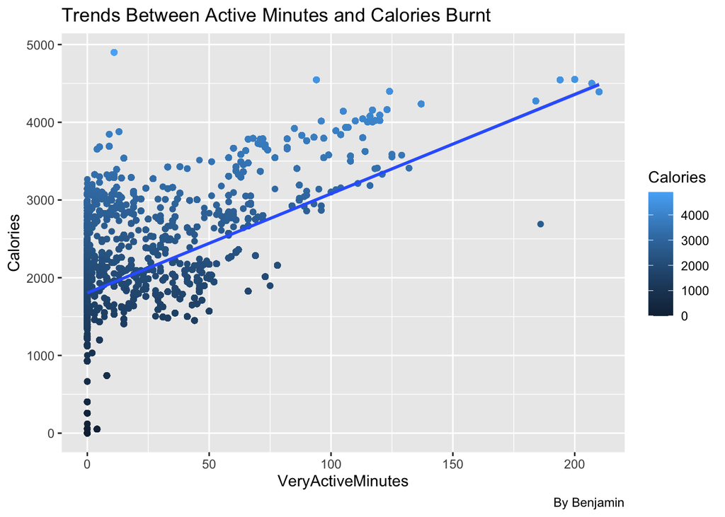

Based on this figure we see a positive relationship, the more active the participant was the more calories they burned.

### Relationship Between Minutes a Sleep and Time in Bed

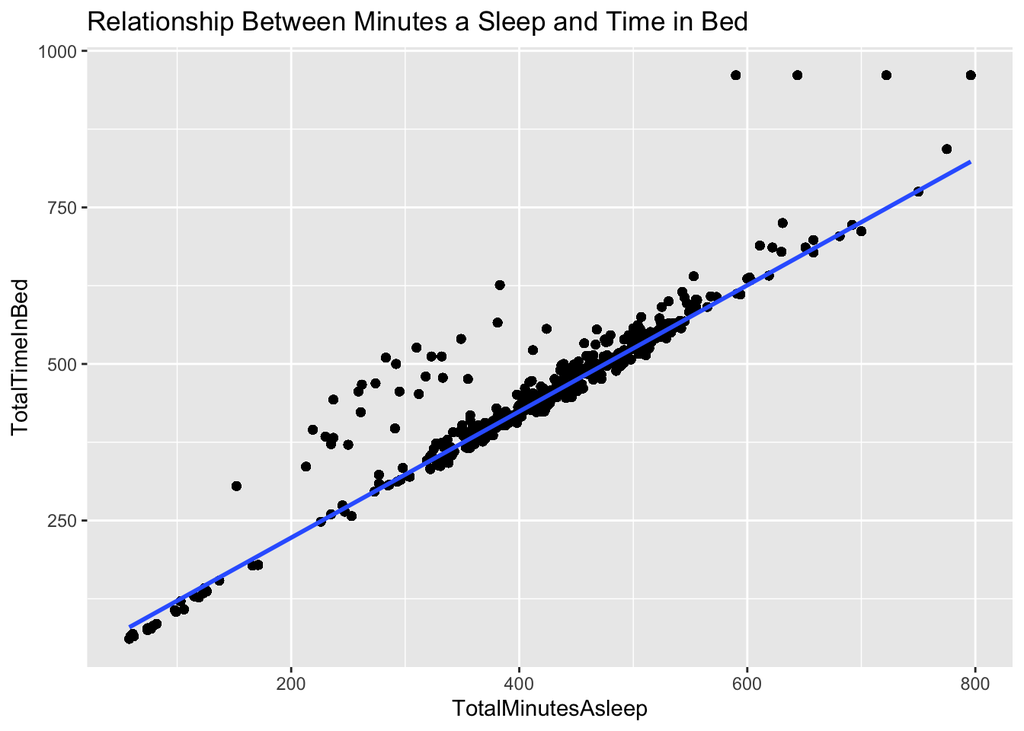

Based on this graph we do see a positive relationship the more time spent in bed the more sleeping time the user got.

### Relationship Between Total Steps and Calories

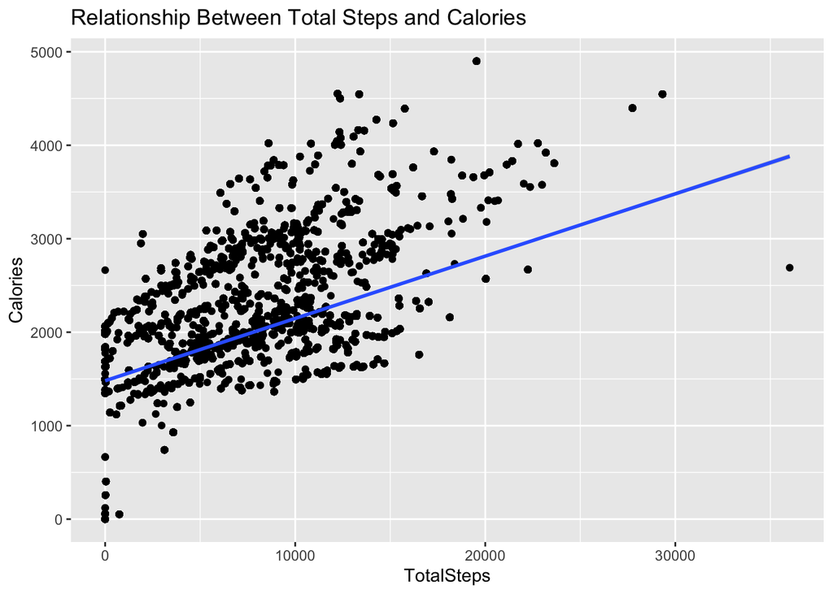

Here we see that the more steps done the more calories burned, we can also see from the graph that the highest calories burned are by users who at least do 10000 to 15000 steps a day.

### Relationship Between Distance and Calories

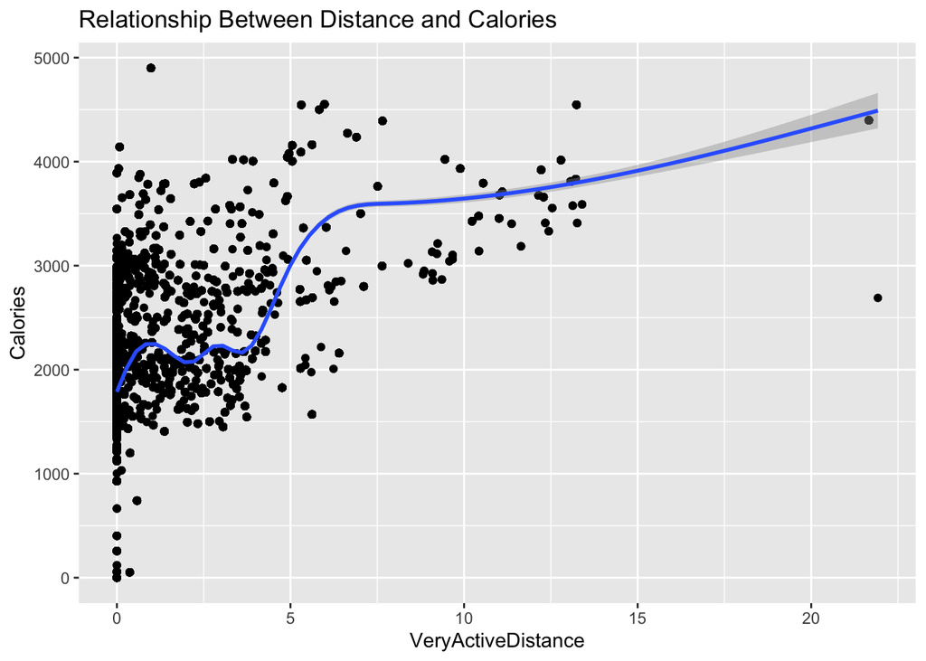

The more distanced used the more calories burnt. Users should be encouraged to make more movements.

### Relationship Between Weight and Calories

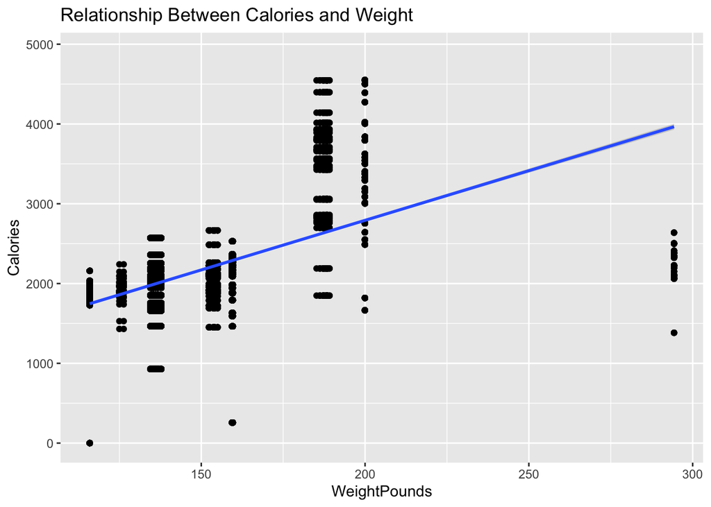

## Recommendations For the Bellabeat App

1. Incorporate a feature that recommends good nutrition with less calories intake.
2. Encourage users to get 10 000 steps a day, this could be done by means of alert notifications, and by giving users a weekly report of how they have been doing on their physical activities. 10 000 is CDC recommended steps a day.
3. Encourage more users to engage in vigorous activities by tracking their activity levels and reminding them to do so by means of alert notifications when they do not reach a certain time limit.
4. There is a lot of time spent on Sedentary time, add a mechanism to notify users to engage in an active activity after a certain time of sedentary minutes have been reached. Also the app could suggest some vigorous activities to users, This could be accomplished by adding some AI features to the app.
5. Alert users of when they have been in bed for a long time.